# HW10

Claire

2018年12月7日

# 3.12

### a.

##### x是mid-parent height，y是height

### b.

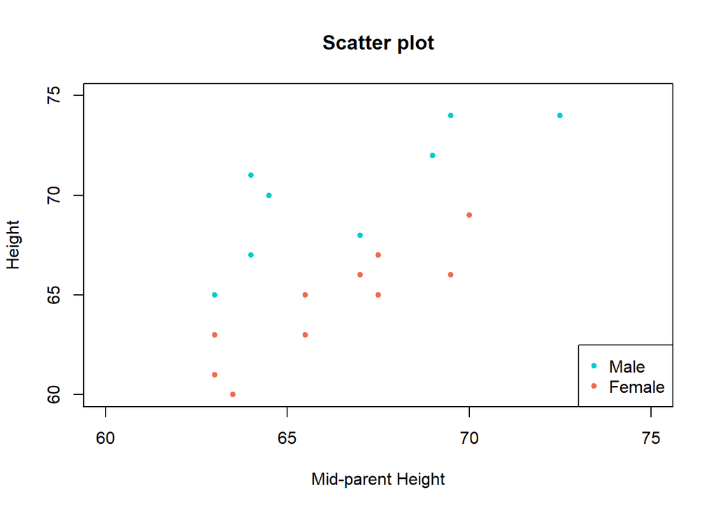

```r
m_height<-c(71,70,74,67,65,72,68,74)
m_mid<-c(64,64.5,72.5,64,63,69,67,69.5)
f_height<-c(60,66,65,66,67,63,69,63,61,65)
f_mid<-c(63.5,67,65.5,69.5,67.5,65.5,70,63,63,67.5)

plot(x=c(60,75),type='n',xlim=c(60,75),xlab='Mid-parent Height',ylab='Height',main='Scatter plot')
points(m_mid,m_height,pch=20,col='cyan3')
points(f_mid,f_height,pch=20,col='coral2')
legend("bottomright",c('Male','Female'),col=c('cyan3','coral2'),pch=c(20,20))
```

### c.

##### 資料大致上呈現學生的身高與父母的平均有正向的線性關係，而且男學生的身高普遍比女生還要高，此外，並沒有非常明顯的outliers。

### d.

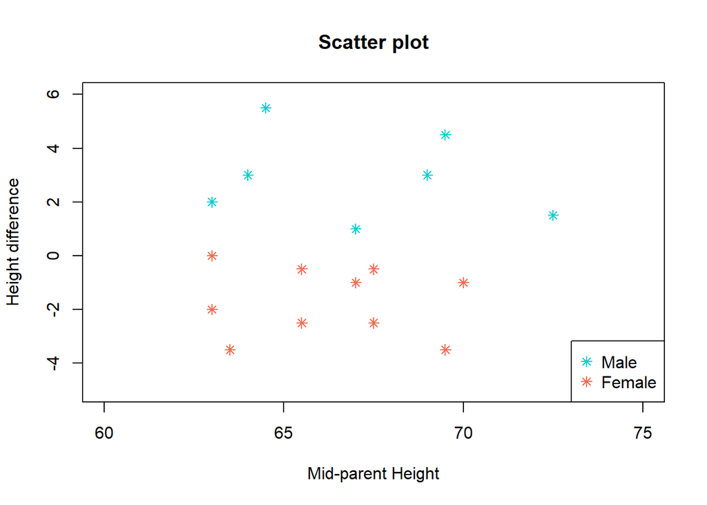

```r
m_diff<-m_height-m_mid
f_diff<-f_height-f_mid
plot(x=c(60,75),type='n',xlim=c(60,75),ylim = c(-5,6),xlab='Mid-parent Height',ylab='Height difference',main='Scatter plot')
points(m_mid,m_diff,pch=8,col='cyan3')
points(f_mid,f_diff,pch=8,col='coral2')
legend("bottomright",c('Male','Female'),col=c('cyan3','coral2'),pch=c(8,8))
```

##### 無論是整體還是分性別看，父母的身高平均與學生與父母的身高差並沒有顯著的正向或負向線性關係，但能看得出來男生通常比父母平均身高要高，而女生則比父母平均身高要矮。

# 3.24

### a.

##### 這個回歸線的斜率是2.34，代表溫度下降的速率是緯度的2.34倍。

### b.

##### estimate: -4.68

##### real: -4

```r
PP_est<-2.34*40
BM_est<-2.34*42
diff_est<-PP_est-BM_est;paste('estimate:',diff_est)
```

```
## [1] "estimate: -4.68000000000001"
```

```r
diff_real<-25-29;paste('real:',diff_real)
```

```
## [1] "real: -4"
```

### c.

##### 48.78

```r
city<-126-2.34*33;city
```

```
## [1] 48.78
```

### d.

```r
predict<-126-2.34*33;predict
```

```
## [1] 48.78
```

```r
res_phoenix<-43-predict;res_phoenix
```

```
## [1] -5.78
```

```r
res_dalllas<-54-predict;res_dalllas
```

```
## [1] 5.22
```

##### 兩個城市的實際溫度都跟預測的不一樣，Phoenix比預期的要冷上5.78度，Dalllas則比預期的要熱上5.22度。

# 3.48

## a.

#### 因為SSTO是用y算出來的，所以不受解釋變項x的影響。

## b.

#### Mid-parents height，因為父母雙方的身高最有可能解釋學生的身高變異狀況，它的SSE是三項解釋變項中最小的。

## c.

```r
SSR=88
SSE=196
r.square=SSR/(SSR+SSE);r.square
```

```
## [1] 0.3098592
```

#### r.square= 0.3098592，顯示父親的身高與學生的身高呈現較弱的關係，解釋效果並不好。

# 3.62

## a.

###### 113.6

```r
equator<-113.6-1.01*0;equator
```

```
## [1] 113.6
```

## b.

###### 因為這個回歸方程式是根據26~47度的地區做出解釋的，0度並不在範圍中。

# 3.82

## b.

```r
predict<-272.63-0.1184*2010;predict
```

```
## [1] 34.646
```

##### 預測值為34.646秒，而真實狀況是34.91秒，其實兩者非常接近，真實狀況比預測值略長。

## c.

```r
0.1184*4
```

```
## [1] 0.4736
```

##### 根據公式，如果奧運每年都比的話每位冠軍的比賽成績都比去年的冠軍少0.1184秒，但奧運四年一次，所以每次奧運的冠軍都預計會比上一位冠軍少掉0.1184*4=0.4736秒。也可以如果一個人想得到下一屆冠軍，他可以往比這屆冠軍的秒數少0.4736秒的目標努力。

## d

```r
272.63-0.1184*2080
```

```
## [1] 26.358
```

##### 因為這個回歸式是以1924~2006年的紀錄而計算出來的，因此只適用於這一段年份，2080不在此限制範圍內，而且人都是有極限的，不會說過了半世紀之後就有可能有26秒多的成績。

## R練習題

##### 檢視資料

```r
data <- read.csv("D:/OneDrive/文件/統計學/Vehicles.csv", stringsAsFactors=F)
head(data)
```

```
##   Year Vehicle  GDP
## 1 1992 2907022 5615
## 2 1993 3238754 6205
## 3 1994 3570497 6784
## 4 1995 3874203 7397
## 5 1996 4146475 8037
## 6 1997 4411911 8717
```

### Scatter plot

##### 從下圖可以看出車子的數量跟GDP呈現正相關的關係，並且有很明顯的線性關係。

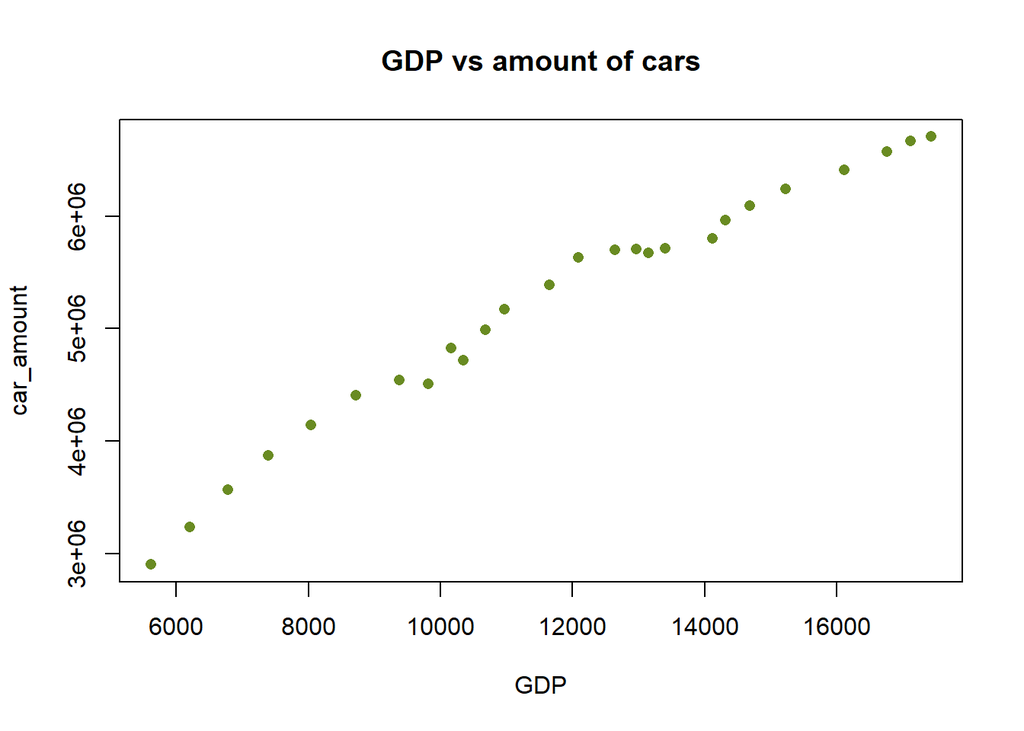

```r
car_amount=data$Vehicle
GDP=data$GDP

#scatterplot記得xy要顛倒
plot(car_amount~GDP,pch=16,cex=1,col="olivedrab4",main="GDP vs amount of cars",xlab="GDP",ylab="car_amount")
```

### Correlation coefficient

##### 兩者之間的相關係數為0.98683，屬於高度相關，代表車子數量和GDP可能有密切的關係。

```r
cor.test(car_amount,GDP)
```

```
##
##  Pearson's product-moment correlation
##
## data:  car_amount and GDP
## t = 29.886, df = 24, p-value < 2.2e-16
## alternative hypothesis: true correlation is not equal to 0
## 95 percent confidence interval:
##  0.9704225 0.9941627
## sample estimates:
##     cor
## 0.98683
```

##### 在這份資料裡面總共有一筆NA值

```r
#Is there any NA value in the data?
length(GDP[is.na(GDP)])
```

```
## [1] 1
```

```r
length(car_amount[is.na(car_amount)])
```

```
## [1] 1
```

##### 從下圖能看出回歸方程式的大致資訊

```r
#simple linear regression
RESULTS=lm(car_amount~GDP)
summary(RESULTS)
```

```
##
## Call:
## lm(formula = car_amount ~ GDP)
##
## Residuals:
##     Min      1Q  Median      3Q     Max
## -413891 -113513    3883  119749  334703
##
## Coefficients:
##              Estimate Std. Error t value Pr(>|t|)
## (Intercept) 1.606e+06  1.251e+05   12.84 3.06e-12 ***
## GDP         3.055e+02  1.022e+01   29.89  < 2e-16 ***
## ---
## Signif. codes:  0 '***' 0.001 '**' 0.01 '*' 0.05 '.' 0.1 ' ' 1
##
## Residual standard error: 175800 on 24 degrees of freedom
##   (1 observation deleted due to missingness)
## Multiple R-squared:  0.9738, Adjusted R-squared:  0.9727
## F-statistic: 893.2 on 1 and 24 DF,  p-value: < 2.2e-16
```

##### 回歸方程式的斜率為305.5035，截距為1605510.4932 ，顯示汽車數量相對於GDP上升的很快

```r
coeff<-coefficients(RESULTS)
RESULTS$coefficients
```

```
##  (Intercept)          GDP
## 1605510.4932     305.5035
```

##### 這是各個y值(汽車數量)相對於預測值的殘差，可以看其實相距不遠，印證相關係數是呈現高度正相關

```r
res<-residuals(RESULTS)
RESULTS$residuals
```

```
##           1           2           3           4           5           6
## -413890.617 -262405.679 -107549.203    8883.155   85632.918  143326.542
##           7           8           9          10          11          12
##   74049.221  -94902.799  -51560.169  116766.006  120742.678  214071.182
##          13          14          15          16          17          18
##  226221.791  334703.246  230943.828   11446.151   51239.045  138865.206
##          19          20          21          22          23          24
## -115501.338  -17788.512   -1116.323  -21755.224 -122004.803 -151697.564
##          25          26
## -169418.823 -227299.913
```

##### 利用回歸方程式預估出來汽車數量在不同GDP底下的預測值

```r
yhat<-fitted.values(RESULTS) #estimated y (yhat)
RESULTS$fitted.values
```

```
##       1       2       3       4       5       6       7       8       9
## 3320913 3501160 3678046 3865320 4060842 4268584 4471439 4604333 4767777
##      10      11      12      13      14      15      16      17      18
## 4708815 4868593 4955662 5164626 5299659 5467380 5701396 5623187 5565447
##      19      20      21      22      23      24      25      26
## 5918914 5977877 6092440 6258634 6527783 6725444 6835425 6930742
```

##### 畫出回歸線，發現大致與資料點的排列方向相符

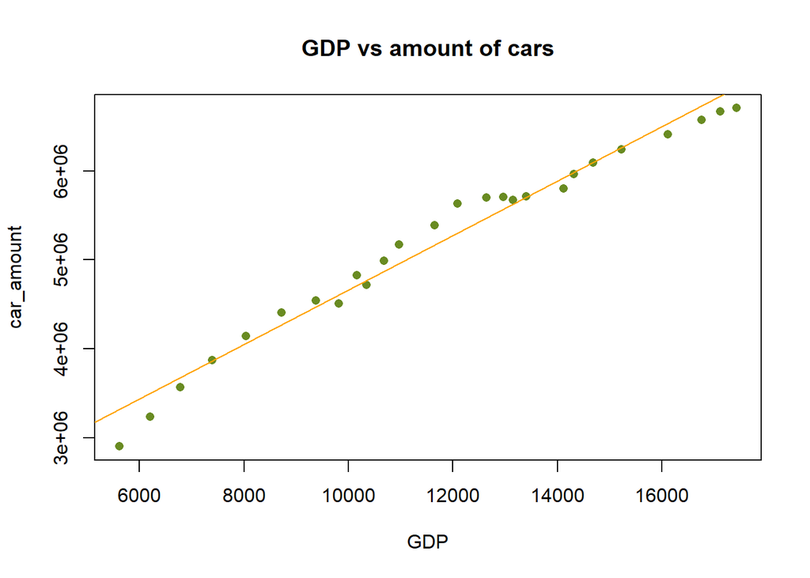

```r
plot(car_amount~GDP,pch=16,cex=1,col="olivedrab4",main="GDP vs amount of cars",xlab="GDP",ylab="car_amount")

abline(RESULTS,col="orange")
```

##### 計匴r square為0.9738332，顯示這個回歸方程式對於原資料具有97.38332%的解釋能力，是具有高度解釋品質。

```r
#anova
anova(RESULTS)
```

```
## Analysis of Variance Table
##
## Response: car_amount
##           Df     Sum Sq    Mean Sq F value    Pr(>F)
## GDP        1 2.7609e+13 2.7609e+13   893.2 < 2.2e-16 ***
## Residuals 24 7.4185e+11 3.0910e+10
## ---
## Signif. codes:  0 '***' 0.001 '**' 0.01 '*' 0.05 '.' 0.1 ' ' 1
```

```r
SSR<-2.7609e+13
SSE<-7.4185e+11
r_square<-SSR/(SSR+SSE);r_square
```

```
## [1] 0.9738332
```

##### 以上數據顯示GDP與汽車數量呈現高度正相關，而且汽車數量相對於GDP上升的很快，因為斜率足足有305.5，並且計算出的回歸方程式具有很好的解釋能力